# Summer 2018 SI learning envt data

Donna McDermott

October 11, 2018

This is a copy of a rmd file of the same name that was started on Aug 21st and is not in this project.

Hello from R Studio! Hello Back from github.

This data was collected in June and July of 2018 to assess how complexity of the environment bees forage in contributes to their ability to remember and apply information. In these trials, ‘complexity of environment’ was adjusted using social information cues. A complex or ‘hard’ learning environment included a misleading social information cue (a dead bee pinned to an unrewarding flower(containing only water).) A simple or ‘easy’ learning environment included a useful social information cue (a dead bee pinned to a rewarding flower([sugar]=1 M)). A control environment with no social information cue was also included. During the treatment, bees foraged individually in a container that exposed them to two flowers (one rewarding blue flower and an unrewarding green flower) for 30 minutes. 7 or 8 trials ran simultaneously in the foraging chamber. During the test, the same bees foraged the next day in the same container as the day before. On this day, both blue and novel violet flowers had equal rewards ([sugar]= 1 M). The test also lasted for 30 minutes, bees were tested independently, and 7 or 8 trials ran simulateously in the chamber at one time. In both treatments and tests, all bees were taken from the same colony where they are fed ad lib Koppert nectar solution and commercial pollen. Bees were starved for a minimim of two hours before entering foraging chamber.

```r
#importing and naming each data set
Te.1559=read.csv("foragingdata_2018.7.12.1559.csv")
colnames(Te.1559) = c("date", "t.day", "flower", "bee", "t.forage", "reward")

Te.1440=read.csv("foragingdata_2018.7.12.1440.csv")
colnames(Te.1440) = c("date", "t.day", "flower", "bee", "t.forage", "reward")

Tr.1500=read.csv("foragingdata_2018.7.11.1500.csv")
colnames(Tr.1500) = c("date", "t.day", "flower", "bee", "t.forage", "reward")

Tr.1416=read.csv("foragingdata_2018.7.11.1416.csv")
colnames(Tr.1416) = c("date", "t.day", "flower", "bee", "t.forage", "reward")

Tr.1330=read.csv("foragingdata_2018.7.11.1330.csv")
colnames(Tr.1330) = c("date", "t.day", "flower", "bee", "t.forage", "reward")

Te.1705=read.csv("foragingdata_2018.7.5.1705.csv")
colnames(Te.1705) = c("date", "t.day", "flower", "bee", "t.forage", "reward")

Te.1625=read.csv("foragingdata_2018.7.5.1625.csv")
colnames(Te.1625) = c("date", "t.day", "flower", "bee", "t.forage", "reward")

Te.1507=read.csv("foragingdata_2018.7.5.1507.csv")
colnames(Te.1507) = c("date", "t.day", "flower", "bee", "t.forage", "reward")

Tr.1438=read.csv("foragingdata_2018.7.4.1438.csv")
colnames(Tr.1438) = c("date", "t.day", "flower", "bee", "t.forage", "reward")

Tr.1337=read.csv("foragingdata_2018.7.4.1337.csv")
colnames(Tr.1337) = c("date", "t.day", "flower", "bee", "t.forage", "reward")

Te.1702=read.csv("foragingdata_2018.6.27.1702.csv")
colnames(Te.1702) = c("date", "t.day", "flower", "bee", "t.forage", "reward")

Te.1607=read.csv("foragingdata_2018.6.27.1607.csv")
colnames(Te.1607) = c("date", "t.day", "flower", "bee", "t.forage", "reward")

Te.1518=read.csv("foragingdata_2018.6.27.1518.csv")
colnames(Te.1518) = c("date", "t.day", "flower", "bee", "t.forage", "reward")

Tr.1635=read.csv("foragingdata_2018.6.26.1635.csv")
colnames(Tr.1635) = c("date", "t.day", "flower", "bee", "t.forage", "reward")

Tr.1518=read.csv("foragingdata_2018.6.26.1518.csv")
colnames(Tr.1518) = c("date", "t.day", "flower", "bee", "t.forage", "reward")

Tr.1434=read.csv("foragingdata_2018.6.26.1434.csv")
colnames(Tr.1434) = c("date", "t.day", "flower", "bee", "t.forage", "reward")

#importing the data set that describes the shapes of flowers, treatment types, etc.
    #this file has a formula for changing space-separated bee id's into dash-separated bee id names
bee.info=read.csv("Donna Bombus ID Data w dashes.csv")

#knitting together data sets into "treatment" files
Full.Treatment1=rbind(Tr.1500,Tr.1416,Tr.1330,Tr.1438,Tr.1337,Tr.1434,Tr.1518,Tr.1635)

#knitting together data sets into "test" files
Full.Test1=rbind(Te.1559,Te.1440,Te.1705,Te.1625,Te.1507,Te.1702,Te.1607,Te.1518)

#removing tester flower from both data sets
Full.Treatment1 =filter(Full.Treatment1, bee !="CE-28-66-01-0B-00-12-E0")
Full.Treatment1 =filter(Full.Treatment1, bee !="D9-28-66-01-0B-00-12-E0")
Full.Test1 =filter(Full.Test1, bee !="CE-28-66-01-0B-00-12-E0")
Full.Test1 =filter(Full.Test1, bee !="D9-28-66-01-0B-00-12-E0")
```

How many visits did each bee make in its half hour treatment or test?

```r
#counting visits and rewards during Treatment runs
#tbl_df(Full.Treatment1)
Total.visits=count(Full.Treatment1, bee)
#Total.visits
Total_Rewards=Full.Treatment1%>%
  group_by(bee) %>%
  summarise(Rewards=sum(reward))
#Total_Rewards

#Total_Rewards
Total_RV=left_join(Total.visits, Total_Rewards, by="bee")
index = which(is.na(Total_RV$Rewards))
Total_RV = Total_RV[-index,]
colnames(Total_RV)=c("bee", "Treatment.Visits", "Treatment.Rewards")
#Total_RV
Avg.Visits=summarise(Total_RV, Treatment.visits=mean(Treatment.Visits), Treatment.reward=mean(Treatment.Rewards))
#Avg.Visits


#Counting visits and rewards during test runs
#tbl_df(Full.Test1)
Total.visitsT=count(Full.Test1, bee)
#Total.visitsT
Total_RewardsT=Full.Test1%>%
  group_by(bee) %>%
  summarise(Rewards=sum(reward))
#Total_RewardsT

#Total_RewardsT
Total_RV_T=left_join(Total.visitsT, Total_RewardsT, by="bee")
index = which(is.na(Total_RV_T$Rewards))
Total_RV_T = Total_RV_T[-index,]
colnames(Total_RV_T)=c("bee", "Test.Visits", "Test.Rewards")
#Total_RV_T
Avg.VisitsT=summarise(Total_RV_T, Test.visits=mean(Test.Visits), Test.reward=mean(Test.Rewards))
#Avg.VisitsT

AllVisits=left_join(Total_RV,Total_RV_T, by="bee") %>%
  filter(Test.Visits>0)
#AllVisits
Avg.AllVisits=cbind(Avg.Visits, Avg.VisitsT)
Avg.AllVisits
```

```
##   Treatment.visits Treatment.reward Test.visits Test.reward
## 1            379.2              9.3    290.4483    9.603448
```

Organizing total visits by treatment types

side note: formula to add dashes to bee ID numbers in excel is =LEFT(B2,2)&“-”&MID(B2,4,2)&“-”&MID(B2,7,2)&“-”&MID(B2,10,2)&“-”&MID(B2,13,2)&“-”&MID(B2,16,2)&“-”&MID(B2,19,2)&“-”&RIGHT(B2,2)

for some reason, flower and pen read the bee ID’s in slightly different formats (pen readings end in 00-00-00, flower readings end in 00-12-E0) I got around this by changing the formula in the excel file to =LEFT(B2,2)&“-”&MID(B2,4,2)&“-”&MID(B2,7,2)&“-”&MID(B2,10,2)&“-”&MID(B2,13,2)&“-”&MID(B2,16,2)&“-”&“12”&“-”&“E0”

```r
BeeData=read.csv("Donna Bombus ID Data w dashes.csv")
BeeDataOrig=read.csv("Donna Bombus ID Data w dashes.csv")
#BeeDataOrig
#tbl_df(BeeData)
#Simple_BeeData=
 # slice(BeeData,41:109) %>%
#  group_by(bee)

BeeData=full_join(AllVisits, BeeData, by="bee")
#BeeData
select(BeeData, bee:Treatment_Type) %>%
  slice(1:50) %>%
  group_by(Treatment_Type) %>%
  summarise(AvgTreatVisits=mean(Treatment.Visits), AvgTreatRewards=mean(Treatment.Rewards),AvgTestVisits=mean(Test.Visits), AvgTestRewards=mean(Test.Rewards))
```

```
## # A tibble: 3 x 5
##   Treatment_Type AvgTreatVisits AvgTreatRewards AvgTestVisits
##   <fct>                   <dbl>           <dbl>         <dbl>
## 1 control                  313.            8.29          317.
## 2 easy                     394.           10.2           239.
## 3 hard                     373.            9.88          251.
## # ... with 1 more variable: AvgTestRewards <dbl>
```

Organizing total visits by flower type

Flowers:

Berry’s thoughts: instead of doing if statements, create a table of flower ID (both types) and date and color, then merge that onto the columns here

```r
#Adding in table of types of day (test v treatment) to data

Full.Data=rbind(Full.Treatment1, Full.Test1)
dayDate= select(Full.Data,date) %>%
  distinct(date) %>%
  slice(c(1,5,6,8,9,10))
#Full.Data

Day=c("treatment","treatment","treatment","test","test","test")
dayDate=cbind(dayDate,Day)
#dayDate

colors=read.csv("Flower color data Summer SI learning envt trials.csv")
names(colors) <- c("flower", "reader", "Day", "color", "reward")
#colors

#need to join dayDate to full trial, then join treatment types and colors to all of that

Full.Data=left_join(Full.Data,dayDate,by="date")
#%>% select(-Days)
colnames(Full.Data)[colnames(Full.Data)=="Day.x"] <- "Day"
#Full.Data

#adding in treatment types
Full.Data.Treatments=full_join(Full.Data, BeeDataOrig, by="bee")
Full.Data.Treatments=Full.Data.Treatments[1:40300,]
#Full.Data.Treatments
#above line is cutting out the bees from "BeeDataOrig" that we tagged (and so put on google sheet) but never tested

#adding in colors
Full.Data.Colors=merge(Full.Data.Treatments, colors, by=c("flower", "Day"), all=TRUE)
Full.Data.Colors= Full.Data.Colors[1:39600,]
#the arranging that happens here puts all the "WARNING" rows at the end of the spreadsheet. it also adds two rows, for reasons unknown. I sliced off the end of the data set to remove the WARNING rows
#Full.Data.Colors is the MOST comprehensive data set (includes more columns and a few NA values)

Full.Data.All= select(Full.Data.Colors, bee, Treatment_Type, reward.x, color, Day)
index = which(is.na(Full.Data.All))
Full.Data.All = Full.Data.All[-index,]
#Full.Data.All
#Full.Data.All removes NA's and focuses in on columns of interest.

#sum of rewards bees got from each color
color.visits=group_by(Full.Data.All, color) %>%
  summarise(Rewards=sum(reward.x))
#color.visits

#making a table of colors and treatments to make analysis easier later
color.treatments=read.csv("color.treatments.csv")
color.treatments=tbl_df(color.treatments)
#color.treatments
#merging that table onto the full data
colordata=full_join(Full.Data.All, color.treatments, by="color")
#colordata
#summarizing that full data by summing up the rewards for each treatment type
sum.colordata=colordata  %>%
  group_by(Treatment_Type, color) %>%
  summarise(sums=sum(reward.x))
#sum.colordata
#There's some issue with sum.colordata, here, where it doesn't include the violet and green visits in the "hard" treatment. It does if you only group by treatment type and color, but then it loses them when you sum up the rewards.

treatment.summaries=spread(sum.colordata, color, sums)
#treatment.summaries
#index = which(is.na(treatment.summaries))
#treatment.summaries = treatment.summaries[-index,]
#treatment.summaries=select(treatment.summaries, blue.test, blue.treatment,green.treatment,violet.test)
#treatment.summaries


#trying to melt data using reshape2
sum.colordata=select(colordata, bee, Treatment_Type, reward.x, pre.post, new.color)
#sum.colordata
#sum.colordata is the rawest data that shows all of and each bee-flower visit.
#colorcast=dcast(sum.colordata, bee + Treatment_Type+pre.post~reward.x+new.color, fun.aggregate = sum)
#trying to just cast without melting did not work, even when I removes "reward.x"

sum.colormelt=melt(sum.colordata)
#sum.colormelt

#tessstcast=dcast(tessstmelt, bee + Treatment_Type+pre.post~new.color, value.var = "value")
#this line was me trying to cast and getting mangled

#sum.colormelt = sum.colormelt[1:39598,]
#this was needed becuase the melt produced a bunch of extra empty rows. but after I came back and edited this code, I removed the empty rows (the "WARNING" rows) much earlier, so it isn't needed any more

#casting data
sum.colorcast=dcast(sum.colormelt, bee + Treatment_Type+pre.post~new.color, fun.aggregate = sum)
#sum.colorcast
head(sum.colorcast)
```

```
##                       bee Treatment_Type pre.post blue not.blue
## 1 08-2B-66-01-0B-00-12-E0           easy     post    5        5
## 2 08-2B-66-01-0B-00-12-E0           easy      pre    2        2
## 3 0B-2B-66-01-0B-00-12-E0           hard     post    3       16
## 4 0E-2B-66-01-0B-00-12-E0           easy     post    4        5
## 5 0E-2B-66-01-0B-00-12-E0           easy      pre   13        8
## 6 0F-2B-66-01-0B-00-12-E0           easy     post    8        2
```

```r
summary(sum.colorcast)
```

```
##      bee            Treatment_Type pre.post       blue
##  Length:118                : 0     post:58   Min.   : 0.000
##  Class :character   control:40     pre :60   1st Qu.: 3.000
##  Mode  :character   easy   :40               Median : 5.000
##                     hard   :38               Mean   : 5.585
##                                              3rd Qu.: 8.000
##                                              Max.   :15.000
##     not.blue
##  Min.   : 0.000
##  1st Qu.: 1.000
##  Median : 3.500
##  Mean   : 3.864
##  3rd Qu.: 6.000
##  Max.   :16.000
```

```r
#there are some bees in here that only have one row. That's okay. I mean, it's annoying, but it's to be expected. The missing rows are due to 2 missing data files caused either by a computer glitch or a me glitch


#GLMing data
SIapplicationGLM2=glmer(cbind(blue, not.blue)~pre.post*Treatment_Type+(1|bee), family=binomial, data=sum.colorcast)
summary(SIapplicationGLM2)
```

```
## Generalized linear mixed model fit by maximum likelihood (Laplace
##   Approximation) [glmerMod]
##  Family: binomial  ( logit )
## Formula: cbind(blue, not.blue) ~ pre.post * Treatment_Type + (1 | bee)
##    Data: sum.colorcast
##
##      AIC      BIC   logLik deviance df.resid
##    700.7    720.1   -343.4    686.7      111
##
## Scaled residuals:
##     Min      1Q  Median      3Q     Max
## -3.9300 -1.1304  0.1869  1.1825  3.0330
##
## Random effects:
##  Groups Name        Variance Std.Dev.
##  bee    (Intercept) 1.126    1.061
## Number of obs: 118, groups:  bee, 68
##
## Fixed effects:
##                                Estimate Std. Error z value Pr(>|z|)
## (Intercept)                      0.2471     0.2821   0.876   0.3811
## pre.postpre                      0.5423     0.2539   2.136   0.0327 *
## Treatment_Typeeasy              -0.5414     0.4036  -1.341   0.1799
## Treatment_Typehard               0.4624     0.4064   1.138   0.2551
## pre.postpre:Treatment_Typeeasy   0.8278     0.3589   2.307   0.0211 *
## pre.postpre:Treatment_Typehard  -1.5228     0.3574  -4.261 2.03e-05 ***
## ---
## Signif. codes:  0 '***' 0.001 '**' 0.01 '*' 0.05 '.' 0.1 ' ' 1
##
## Correlation of Fixed Effects:
##                      (Intr) pr.pst Trtmnt_Typs Trtmnt_Typh
## pre.postpre          -0.394
## Trtmnt_Typs          -0.700  0.272
## Trtmnt_Typh          -0.694  0.275  0.485
## pr.pstpr:Trtmnt_Typs  0.281 -0.702 -0.426      -0.194
## pr.pstpr:Trtmnt_Typh  0.278 -0.716 -0.189      -0.418
##                      pr.pstpr:Trtmnt_Typs
## pre.postpre
## Trtmnt_Typs
## Trtmnt_Typh
## pr.pstpr:Trtmnt_Typs
## pr.pstpr:Trtmnt_Typh  0.497
```

```r
a=filter(sum.colorcast, pre.post == "pre")
SIapplicationGLM3=glmer(cbind(blue, not.blue)~Treatment_Type+(1|bee), family=binomial, data=a)
summary(SIapplicationGLM3)
```

```
## Generalized linear mixed model fit by maximum likelihood (Laplace
##   Approximation) [glmerMod]
##  Family: binomial  ( logit )
## Formula: cbind(blue, not.blue) ~ Treatment_Type + (1 | bee)
##    Data: a
##
##      AIC      BIC   logLik deviance df.resid
##    270.3    278.7   -131.2    262.3       56
##
## Scaled residuals:
##      Min       1Q   Median       3Q      Max
## -1.03376 -0.19834 -0.01028  0.30693  0.99025
##
## Random effects:
##  Groups Name        Variance Std.Dev.
##  bee    (Intercept) 3.275    1.81
## Number of obs: 60, groups:  bee, 60
##
## Fixed effects:
##                     Estimate Std. Error z value Pr(>|z|)
## (Intercept)         0.760133   0.001814   419.0   <2e-16 ***
## Treatment_Typeeasy  0.580674   0.001814   320.2   <2e-16 ***
## Treatment_Typehard -1.047216   0.001813  -577.6   <2e-16 ***
## ---
## Signif. codes:  0 '***' 0.001 '**' 0.01 '*' 0.05 '.' 0.1 ' ' 1
##
## Correlation of Fixed Effects:
##             (Intr) Trtmnt_Typs
## Trtmnt_Typs 0.000
## Trtmnt_Typh 0.000  0.000
## convergence code: 0
## Model failed to converge with max|grad| = 0.0391811 (tol = 0.001, component 1)
```

```r
#lm(x ~ y + relevel(b, ref = "3"))
```

sum.colordata for ggplot, where x=treatment (with sub-xs for treatment vs. test) and y is % change in rewards from blue vs. not blue (i.e. amount of preference for blue). see sketch from 10/3 in planner

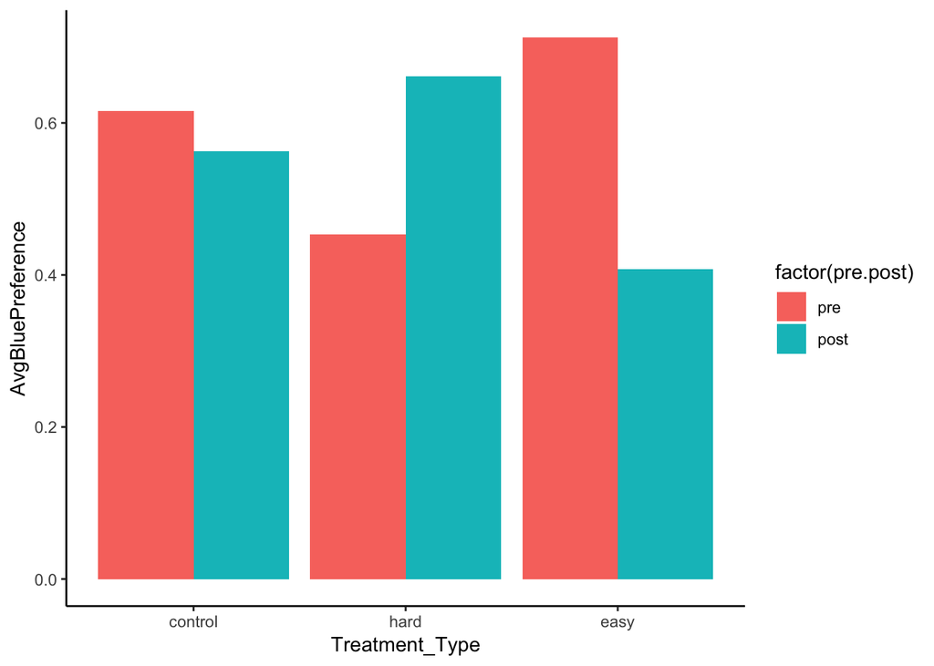

```r
#putting summary stats in sum.colordata so I can plot them

#head(sum.colordata)

color.visits=group_by(Full.Data.All, color) %>%
  summarise(Rewards=sum(reward.x))

RewardsPerBee=sum.colordata %>%
  group_by(Treatment_Type,pre.post, bee, new.color)%>%
  summarise(TotalReward=sum(reward.x)) %>%
  arrange(bee)

#RewardsPerBee

#need to cast this so that last two columns are blue column and not blue column
#...in retrospect, i think i coud just use sum.colorcast, above.
#head(sum.colorcast)

RewardsPerTreatment=sum.colorcast %>%
  mutate(BluePreference=blue/(blue+not.blue)) %>%
  group_by(pre.post,Treatment_Type) %>%
  summarise(AvgBluePreference=mean(BluePreference), SdBluePreference=sd(BluePreference), SumBlueRewards=sum(blue), SumTotalRewards=sum(blue+not.blue))

#class(RewardsPerTreatment$pre.post) #factor
RewardsPerTreatment$pre.post = factor(RewardsPerTreatment$pre.post, levels(factor(RewardsPerTreatment$pre.post))[c(2,1)])
#below is alva's code that I used for reference in reordering factors
#scen.frame$rc = factor(scen.frame$rc,levels(factor(scen.frame$rc))[c(1,4,2,5,3,6)])

#now reordering hard and easy so they're the right colors.
RewardsPerTreatment$Treatment_Type = factor(RewardsPerTreatment$Treatment_Type, levels(factor(RewardsPerTreatment$Treatment_Type))[c(1,3,2)])

dodge <- position_dodge(width = 0.9)

g1 <- ggplot(data = RewardsPerTreatment, aes(x = Treatment_Type, y = AvgBluePreference, fill=factor(pre.post))) +
  geom_bar(stat = "identity", position = position_dodge()) +
  theme_classic()

g1
```

```r
#geom_errorbar(aes(ymax = AvgBluePreference+SdBluePreference, ymin = AvgBluePreference-SdBluePreference), position = dodge, width = 0.2)
```

```r
#calculating confidence intervals
require(binom)
RpTconfint=binom.confint(x=RewardsPerTreatment$SumBlueRewards, n=RewardsPerTreatment$SumTotalRewards, conf.level=.95, methods = "agresti-coull")
RpTconfint
```

```
##          method   x   n      mean     lower     upper
## 1 agresti-coull 112 197 0.5685279 0.4986950 0.6357394
## 2 agresti-coull  79 170 0.4647059 0.3913370 0.5396346
## 3 agresti-coull 120 190 0.6315789 0.5609659 0.6969769
## 4 agresti-coull 109 167 0.6526946 0.5777040 0.7208184
## 5 agresti-coull 151 209 0.7224880 0.6580518 0.7788931
## 6 agresti-coull  88 182 0.4835165 0.4120083 0.5557061
```

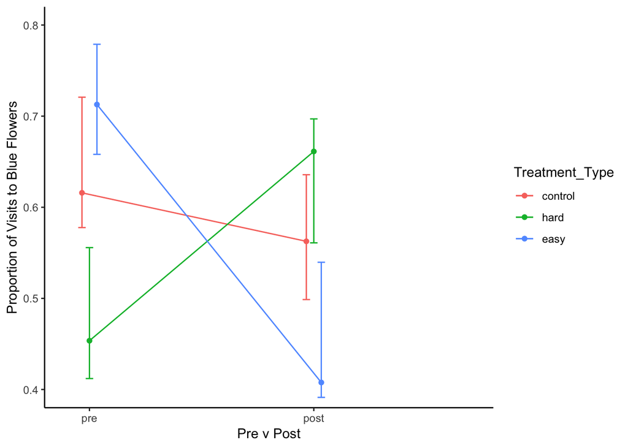

```r
#selecting the upper and lower bounds from the conf int table to add to RewardsPerTreatment
RpTUpLow=select(RpTconfint, lower, upper )
RewardsPerTreatment=bind_cols(RewardsPerTreatment,RpTUpLow)

#plot 2- berry's aesthetic

pd <- position_dodge(width = 0.1)

plot2 <- ggplot(RewardsPerTreatment, aes(color = Treatment_Type, y = AvgBluePreference, x = pre.post))
plot2 <- plot2 + geom_point(position=pd) + geom_line(aes(group = Treatment_Type), position=pd)
plot2 = plot2 + labs(x="Pre v Post", y="Proportion of Visits to Blue Flowers")
plot2= plot2 + theme_classic() + geom_errorbar(aes(ymin=lower, ymax=upper, width=.1), position=pd) + coord_cartesian(xlim = c(1.4,2.2), ylim = c(0.4,0.8))


plot2
```

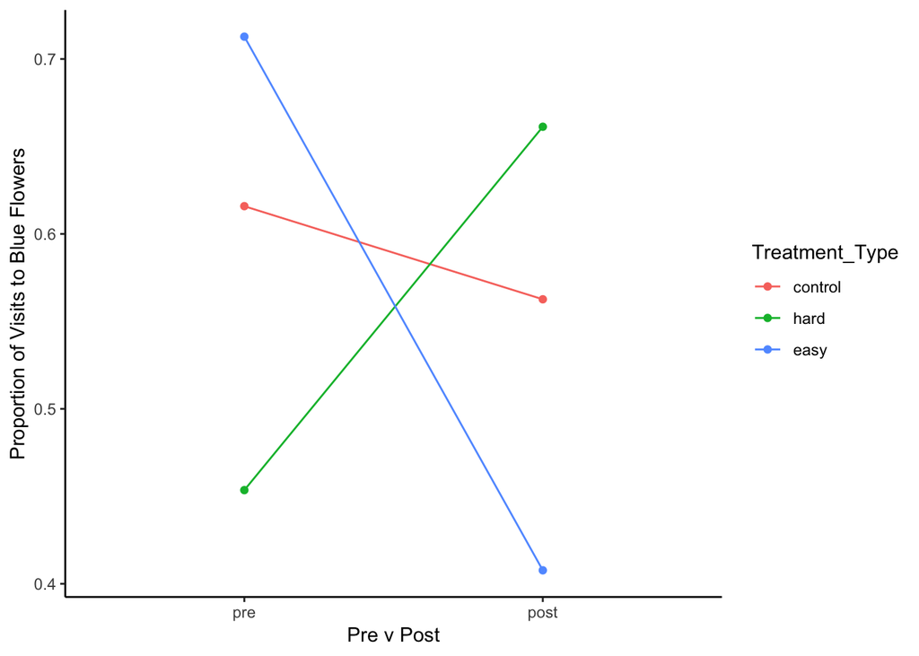

```r
#offsetting the error bars example from stack exchange
#pd <- position_dodge(width = 0.4)

#ggplot(YearlyDensity, aes(x = Year, y = mean, colour = Station, group = Station)) +
#  geom_errorbar(aes(ymin = mean-se, ymax = mean+se),
#                colour = "black", width = 0.2, position = pd) +
#  geom_line(size = .8, position = pd) +
#  geom_point(size = 4, shape = 18, position = pd) +




plot3 <- ggplot(RewardsPerTreatment, aes(color = Treatment_Type, y = AvgBluePreference, x = pre.post))
plot3 <- plot3 + geom_point() + geom_line(aes(group = Treatment_Type))
plot3 = plot3 + labs(x="Pre v Post", y="Proportion of Visits to Blue Flowers")
plot3= plot3 + theme_classic()

#adding in confidence intervals
#plot2=plot2+ geom_pointrange(x, y, ymin, ymax, alpha, color, fill, linetype,
#shape, size)


plot3
```

```r
#make error bars narrower. show blue and green first, then layer in red.
```

rerun GLMM with nested random effects take CI out of this figure, but keep this figure at the end of the talk maybe plot by bee with big bold trend lines for the groups (the data above)

# Permutation Tests for Pre data

Are the pre values significantly different than 50% visitation to blue flower?

```r
#making table of blue=success for all treatments

  #making table for translation that blue=success
success_table=read.csv("blue.success.csv")
success_table
```

```
##   new.color blue.success
## 1      blue            1
## 2  not.blue            0
```

```r
success_colordata= colordata %>%
  select(Treatment_Type, reward.x, pre.post, new.color) %>%
  filter(reward.x==1) %>%
  filter(pre.post=="pre") %>%
  left_join(success_table, by="new.color")

#making control data vector
control_colordata= success_colordata %>%
  filter(Treatment_Type=="control")
control_vector=control_colordata$blue.success
control_vector
```

```
##   [1] 1 1 1 1 1 1 1 1 1 1 1 1 1 1 1 1 1 1 1 1 1 1 1 1 1 1 1 1 1 1 1 1 1 1 1
##  [36] 1 1 1 1 1 1 1 1 1 1 1 0 0 0 0 0 0 0 0 0 0 0 0 0 0 0 0 0 0 0 0 0 0 0 0
##  [71] 0 0 0 0 0 0 0 0 0 0 0 0 0 0 0 0 0 0 0 0 0 0 0 1 1 1 1 1 1 1 1 1 1 1 1
## [106] 1 1 1 1 0 0 1 1 1 1 1 1 1 1 1 1 1 1 1 1 1 1 1 1 1 1 1 1 0 0 0 0 0 0 0
## [141] 0 0 1 1 1 1 1 1 1 1 1 1 1 1 1 1 1 1 1 1 1 1 1 1 1 1 1
```

```r
#n=167

#making hard data vector
hard_colordata= success_colordata %>%
  filter(Treatment_Type=="hard")
hard_vector=hard_colordata$blue.success
#n=182

#making easy data vector
easy_colordata= success_colordata %>%
  filter(Treatment_Type=="easy")
easy_vector=easy_colordata$blue.success
#n=209

#actual permutation test for control data
#this is two-tailed and should give z score and  p value

  #making binomial distribution with mean of .5
control_null=rbinom(n=167, prob=0.5, size=1)

require(coin)
control_perm=independence_test(control_vector ~ control_null)
control_perm
```

```
##
##  Asymptotic General Independence Test
##
## data:  control_vector by control_null
## Z = -0.34138, p-value = 0.7328
## alternative hypothesis: two.sided
```

```r
#   Asymptotic General Independence Test

#data:  control_vector by control_null
#Z = -0.34138, p-value = 0.7328
#alternative hypothesis: two.sided


#actual permutation test for hard data
hard_null=rbinom(n=182, prob=0.5, size=1)

hard_perm=independence_test(hard_vector ~ hard_null)
hard_perm
```

```
##
##  Asymptotic General Independence Test
##
## data:  hard_vector by hard_null
## Z = -1.165, p-value = 0.244
## alternative hypothesis: two.sided
```

```r
#   Asymptotic General Independence Test

#data:  hard_vector by hard_null
#Z = 0.94201, p-value = 0.3462
#alternative hypothesis: two.sided

#actual permutation test for easy data
easy_null=rbinom(n=209, prob=0.5, size=1)

easy_perm=independence_test(easy_vector ~ easy_null)
easy_perm
```

```
##
##  Asymptotic General Independence Test
##
## data:  easy_vector by easy_null
## Z = 0.11255, p-value = 0.9104
## alternative hypothesis: two.sided
```

```r
#   Asymptotic General Independence Test

#data:  easy_vector by easy_null
#Z = -2.0294, p-value = 0.04241
#alternative hypothesis: two.sided

#plotting the three of these
```

# Permutation tests for Post Data

Were bees foraging nonrandomly on test days?

```r
post_success_colordata= colordata %>%
  select(Treatment_Type, reward.x, pre.post, new.color) %>%
  filter(reward.x==1) %>%
  filter(pre.post=="post") %>%
  left_join(success_table, by="new.color")

#making control data vector
post_control_colordata= post_success_colordata %>%
  filter(Treatment_Type=="control")
post_control_vector=post_control_colordata$blue.success
#n=197

#making hard data vector
post_hard_colordata= post_success_colordata %>%
  filter(Treatment_Type=="hard")
post_hard_vector=post_hard_colordata$blue.success
#n=190

#making easy data vector
post_easy_colordata= post_success_colordata %>%
  filter(Treatment_Type=="easy")
post_easy_vector=post_easy_colordata$blue.success
#n=170

#actual permutation test for control data
#this is two-tailed and should give z score and  p value

  #making binomial distribution with mean of .5
post_control_null=rbinom(n=197, prob=0.5, size=1)

post_control_perm=independence_test(post_control_vector ~ post_control_null)
post_control_perm
```

```
##
##  Asymptotic General Independence Test
##
## data:  post_control_vector by post_control_null
## Z = 1.3095, p-value = 0.1904
## alternative hypothesis: two.sided
```

```r
#   Asymptotic General Independence Test

#data:  post_control_vector by post_control_null
#Z = 2.0115, p-value = 0.04427
#alternative hypothesis: two.sided



#actual permutation test for hard data
post_hard_null=rbinom(n=190, prob=0.5, size=1)

post_hard_perm=independence_test(post_hard_vector ~ post_hard_null)
post_hard_perm
```

```
##
##  Asymptotic General Independence Test
##
## data:  post_hard_vector by post_hard_null
## Z = 0.14223, p-value = 0.8869
## alternative hypothesis: two.sided
```

```r
#   Asymptotic General Independence Test

#data:  post_hard_vector by post_hard_null
#Z = 0.20641, p-value = 0.8365
#alternative hypothesis: two.sided

#actual permutation test for easy data
post_easy_null=rbinom(n=170, prob=0.5, size=1)

post_easy_perm=independence_test(post_easy_vector ~ post_easy_null)
post_easy_perm
```

```
##
##  Asymptotic General Independence Test
##
## data:  post_easy_vector by post_easy_null
## Z = -0.010824, p-value = 0.9914
## alternative hypothesis: two.sided
```

```r
#   Asymptotic General Independence Test

#data:  post_easy_vector by post_easy_null
#Z = 0.68307, p-value = 0.4946
#alternative hypothesis: two.sided

#perm_summary=read.csv("PermutationTestPvaluesSummerFCdata.csv")
#?
#pre.post   control easy      hard
#pre        0.7328  0.04241 0.3462
#post       0.04427 0.4996  0.8365
```

re-do it berry suggests doing simulation mself. create binomail null vector and re-run it 9999 times (creating my own vector of proportions). then plot proportions as a histogram, then plot your one empirical proportion. the x location of that line is its value. p value is the rank of my data point (how many are bigger) relative to distribution. or do a x2 test expectation is total number of visits split 50% into blue and 50% into not blue. (if n is odd, put bigger number with bigger observed value) observed is the actual number of blue vists and not blue visits.